# Dados Brasileiros no R

02/12/2019

## Pacotes de Dados Brasileiros

## Pacotes para Dados Macro

- SidraR: Dados do IBGE
- rbcb: Dados do Banco Central
- BETS: Dados de origens diversas

## Pacotes para Dados Micro no Brasil

- PNADcIBGE: Dados da PNADC
- MicrodadosBR: Dados de origens diversas
- Microdatasus: Dados do DataSUS
- ElectionsBR: Dados eleitorais

## SidraR

- Basicamente, permite baixar qualquer tabela que esteja no SIDRA - IBGE
- É possivel escolher qualquer periodo ou subgrupo do site
- O maior problema é que é preciso saber o numero das tabelas
- Sabendo disso, no R você descobre por onde pode explorar

## Como baixar

```r
install.packages("devtools")
devtools::install_github('wilsonfreitas/rbcb')
install.packages("sidrar")
install.packages("BETS")
```

## Renda Média na PNAD por UF

```r
library(sidrar)
# info_sidra(1860)
estados_renda <- get_sidra(1860,
                           variable = 772,
                          period = "all",
                          geo = "State",
                       classific = c("c12021"),
                       category = list(106827))

head(estados_renda)
```

```
##   Nível Territorial (Código)    Nível Territorial
## 2                          3 Unidade da Federação
## 3                          3 Unidade da Federação
## 4                          3 Unidade da Federação
## 5                          3 Unidade da Federação
## 6                          3 Unidade da Federação
## 7                          3 Unidade da Federação
##   Unidade da Federação (Código) Unidade da Federação Ano (Código)  Ano
## 2                            11             Rondônia         2001 2001
## 3                            11             Rondônia         2002 2002
## 4                            11             Rondônia         2003 2003
## 5                            11             Rondônia         2004 2004
## 6                            11             Rondônia         2005 2005
## 7                            11             Rondônia         2006 2006
##   Variável (Código)
```

[output cut: 34 more lines]

## Plotando a Renda Media em 2014

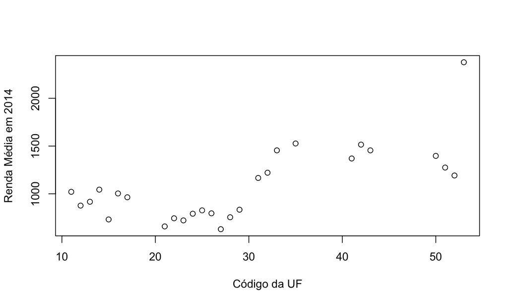

```r
plot(subset(estados_renda, Ano == 2014)$`Unidade da Federação (Código)`,
     subset(estados_renda, Ano == 2014)$Valor,
     ylab = "Renda Média em 2014", xlab = "Código da UF")
```

## RBCB

- Pode baixar dados não apenas de series que o BC adquire de outras entidades, mas tambem as que produz.
- Por exemplo, as de **expectativas do mercado.**
- É fácil ajustar o resultado da chamada para o período que você está analisando.

## IPCA, Dólar Corrente e Expectativa do PIB

```r
library(rbcb)
ipca <- get_series(c(IPCA = 433), last = 24)
dolar <- get_currency("USD",
                      "2017-11-30",
                      "2019-11-26")

expPIBnov19 <- get_quarterly_market_expectations("PIB Total",
                                                 end_date = "2019-11-22",
                                                 `$top` = 5)
```

## Plotando Dólar e Inflação

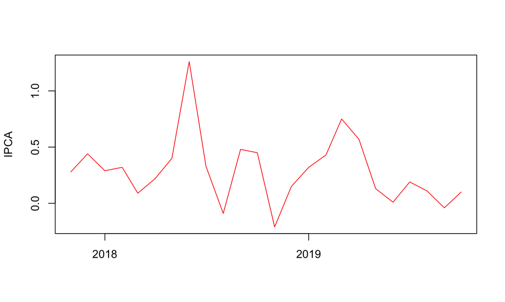

```r
plot(x = ipca$date, y = ipca$IPCA,
     ylab="IPCA",  xlab="",
     type="l", col="red")
```

## Plotando Dolar e Inflação

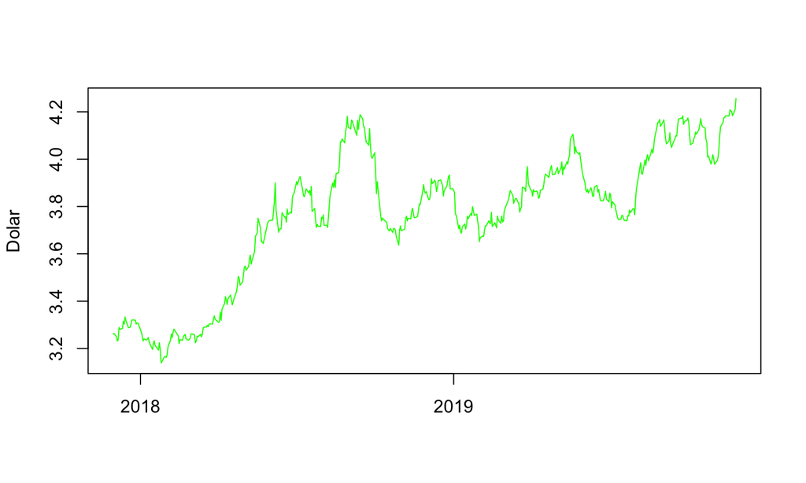

```r
plot(x = dolar$date, y = dolar$ask,
     ylab = "Dolar", xlab = "",
     type = "l", col = "green")
```

## Plotando Expecativa do PIB futuro

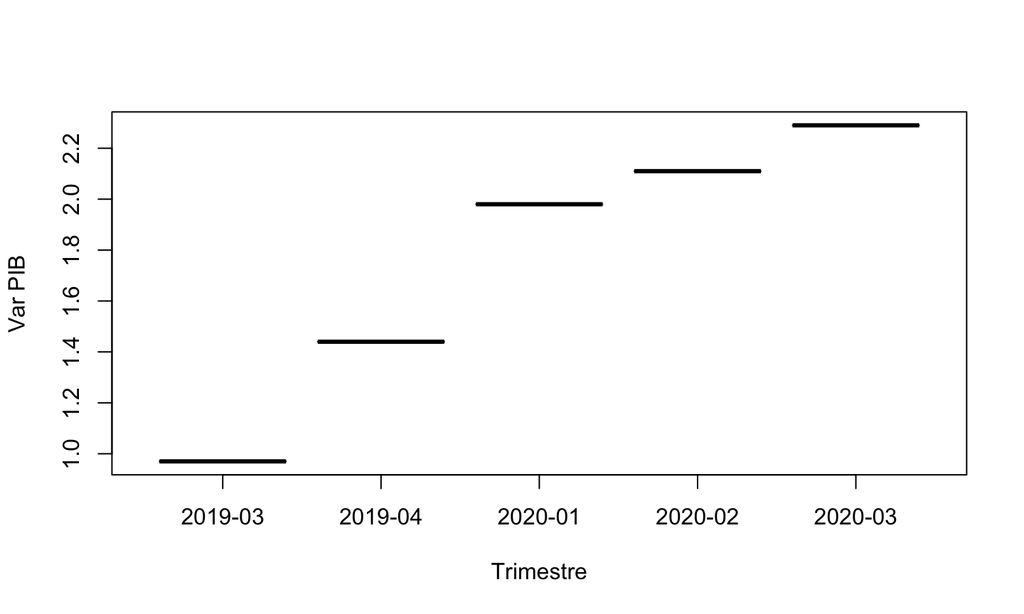

```r
plot(x = expPIBnov19$reference_quarter, y = expPIBnov19$mean,
     ylab = "Var PIB",  xlab = "Trimestre")
```

## BETS

- Base de dados de diversas fontes:
- BCB
- IBGE
- FGV (e Ibre)
- Sidra
- No entanto, bastante pesado.

## Fontes de Dados

```r
library(BETS)
BETSsources()
```

```
## The sources available at BETS, to date, are:
##  >  Banco Central, IBGE, Sidra, FGV
```

## Confiança do Consumidor

```r
confs <- BETSsearch(description = "confidence")
```

```
##
## BETS-package: Found 5 out of 18706 time series.
```

```r
head(confs)
```

```
## # A tibble: 5 x 7
##   code  description           unit  periodicity start  last_value   source
##   <chr> <chr>                 <chr> <chr>       <chr>  <chr>        <chr>
## 1 12544 Consumer Confidence … Index M           01/09… jan/2007     Cepa/U…
## 2 4393  Consumer confidence … Index M           31/03… mar/2018     Fecome…
## 3 7341  Business confidence … Index Q           31/07… "2\xba Quar… CNI
## 4 7342  Business confidence … Index Q           31/07… "2\xba Quar… CNI
## 5 7343  Business confidence … Index Q           31/07… "2\xba Quar… CNI
```

## Confiança do Consumidor

```r
confd <- BETSget(4393,
                 data.frame = TRUE)
```

## Plotando a Confiança do Consumidor

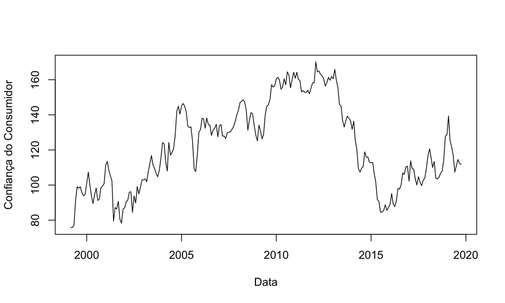

```r
plot(x = confd$date, y = confd$value,
     ylab = "Confiança do Consumidor", xlab = "Data",
     type = "l")
```

## Dados Micro: PNADcIBGE

- Baixa e/ou lê os microdados das PNAD Contínuas
- Pode baixar um subset pré definido de variáveis
- Pode baixar já com os pesos amostrais complexos
- Sua origem vem de um iniciativa de leitura de praticamente todo microdado do IBGE: http://asdfree.com/

## Exemplo: PNADC 2019-03

```r
library(PNADcIBGE)
library(survey)

dadosPNADc <- get_pnadc(year = 2019,
                        quarter = 3,
                        vars=c("V2009","VD4002","VD4019"),
                        design=TRUE)
```

## PNADC 2019-03: Desemprego por idade

```r
svyciprop(~VD4002, design = subset(dadosPNADc, V2009 >= 18 & V2009 <= 24))
svyciprop(~VD4002, design = subset(dadosPNADc, V2009 >= 25 & V2009 <= 34))
svyciprop(~VD4002, design = subset(dadosPNADc, V2009 >= 35 & V2009 <= 44))
svyciprop(~VD4002, design = subset(dadosPNADc, V2009 >= 45 & V2009 <= 64))
svyciprop(~VD4002, design = subset(dadosPNADc, V2009 >= 65 & V2009 <= 80))
```

[output not shown]

## PNADC 2019-03: Renda do Trabalho por idade

```r
svymean(~VD4019,design=subset(dadosPNADc,V2009 >= 18 & V2009 <= 24),na.rm=T)
svymean(~VD4019,design=subset(dadosPNADc,V2009 >= 25 & V2009 <= 34),na.rm=T)
svymean(~VD4019,design=subset(dadosPNADc,V2009 >= 35 & V2009 <= 44),na.rm=T)
svymean(~VD4019,design=subset(dadosPNADc,V2009 >= 45 & V2009 <= 64),na.rm=T)
svymean(~VD4019,design=subset(dadosPNADc,V2009 >= 65 & V2009 <= 80),na.rm=T)
```

[output not shown]

## MicrodadosBR

- Agrega diversas fontes de microdados:
- PNAD
- Censo
- PME
- POF
- Censo Escolar
- Censo Ed. Superior
- Caged
- RAIS

## Instalação

```r
install.packages("devtools")
install.packages("stringi")
devtools::install_github("lucasmation/microdadosBrasil")
```

## Baixando o Censo Ed. Superior

```r
library('microdadosBrasil')

download_sourceData("CensoEducacaoSuperior",
                    i = 2004,
                    unzip = TRUE)

institutos <- read_CensoEducacaoSuperior(ft = 'ies', i = 2004)
```

## Valor investido em pesquisa por Tipo de Instituição

```r
tab <- as.data.frame(table(institutos$DS_CATEGORIA_ADMINISTRATIVA))

for(x in 1:6){
tab$Pesquisa[x] = sum(subset(institutos,
                           DS_CATEGORIA_ADMINISTRATIVA==tab$Var1[x])$VL_DES_PESQUISA)
  }
```

## Microdatasus: Dados do DataSUS

- Basicamente baixa e limpa dados disponíveis no DataSUS
- Por sua vez, os dados do DataSUS são bem completos.

## Instalação

```r
devtools::install_github("rfsaldanha/microdatasus")
```

## Infartos por município no Rio de Janeiro

```r
library(microdatasus)

infartos <- c("I21", "I210", "I211", "I212", "I213", "I214", "I219")
RJsus <- fetch_datasus(year_start = 2015,
                       year_end = 2017,
                       uf = "RJ",
                       information_system = "SIM-DO")
RJsus <- process_sim(RJsus)
RJsus <- RJsus %>%
  filter(CAUSABAS %in% infartos | CAUSABAS_O %in% infartos) %>%
  rename(code_muni=CODMUNRES)

infartosRJ <- as.data.frame(table(RJsus$code_muni)) %>%
  rename(code_muni=Var1)
```

## Infartos por município no Rio de Janeiro

Agora vamos ter o nome dos municípios e seus códigos em um dataframe

```r
RJsus <- RJsus %>% select(code_muni,munResNome) %>% unique %>%
  mutate(code_muni = as.character(code_muni))

#Agora juntando-os

infartosRJ  <- left_join(infartosRJ,RJsus,by="code_muni") %>%
  filter(code_muni != "330000")
```

## geobr e brazilmaps

- geobr baixa vários shapefiles do Brasil em formato sf.
- Já o brazilmaps baixa os shapefiles em vários formatos.
- O brazilmaps também tem informações geográficas.

## Instalação e uso

```r
#install.packages("geobr")
library(geobr)
library(sf)
library(brazilmaps)

RJ <- read_municipality(code_muni=33,year=2010) %>%
  mutate(code_muni=as.character(substr(code_muni,1,6)))
```

[output not shown]

```r
PopRJ <- brazilmaps::pop2017 %>%
  mutate(UF=substr(mun,1,2),
         code_muni=as.character(substr(mun,1,6))) %>%
  filter(UF=="33")
```